# [TWD] Praca domowa nr 2

Szymon Maksymiuk

21 października 2018

# Wstęp

W swojej drugiej pracy domowej postanowiłem wziąć na warsztat wykres Bartka Granata. Nie uważam jakkolwiek ażeby wykonany był błędnie, sądzę po prostu, że sposób, który przedstawię poniżej, będzie bardziej korzystny dla danych nam zaprezentowanych.

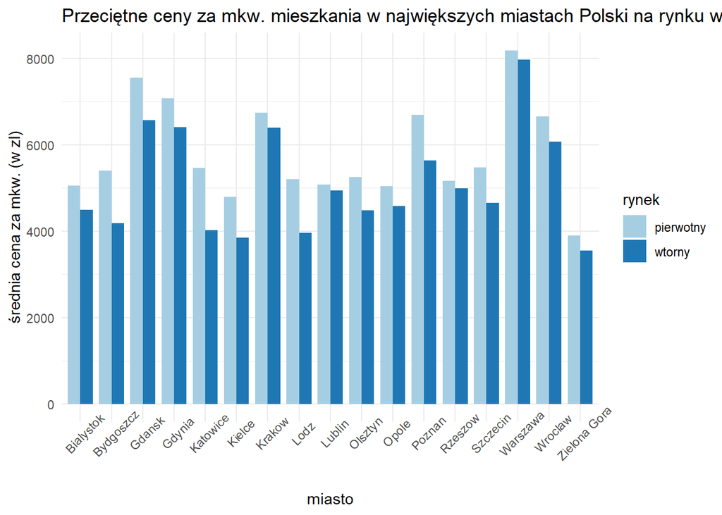

```r
library(reshape2)
library(ggplot2)
dane <- read.csv("dane.csv", sep = ";")
dat.m<-melt(dane, id.vars = "miasto")
names(dat.m) <- c("miasto", "rynek", "cena")
ggplot(data = dat.m,aes(x = miasto, y = cena, fill = rynek))+
  geom_bar(stat = "identity", width =  0.8, position=position_dodge())+
  scale_fill_brewer(palette="Paired")+
  theme_minimal() +
  labs(title="Przeciętne ceny za mkw. mieszkania w największych miastach Polski na rynku wtórnym i pierwotnym", x="miasto", y = "średnia cena za mkw. (w zl)") +
  theme(axis.text.x = element_text(angle = 45))
```

# Wersja poprawiona

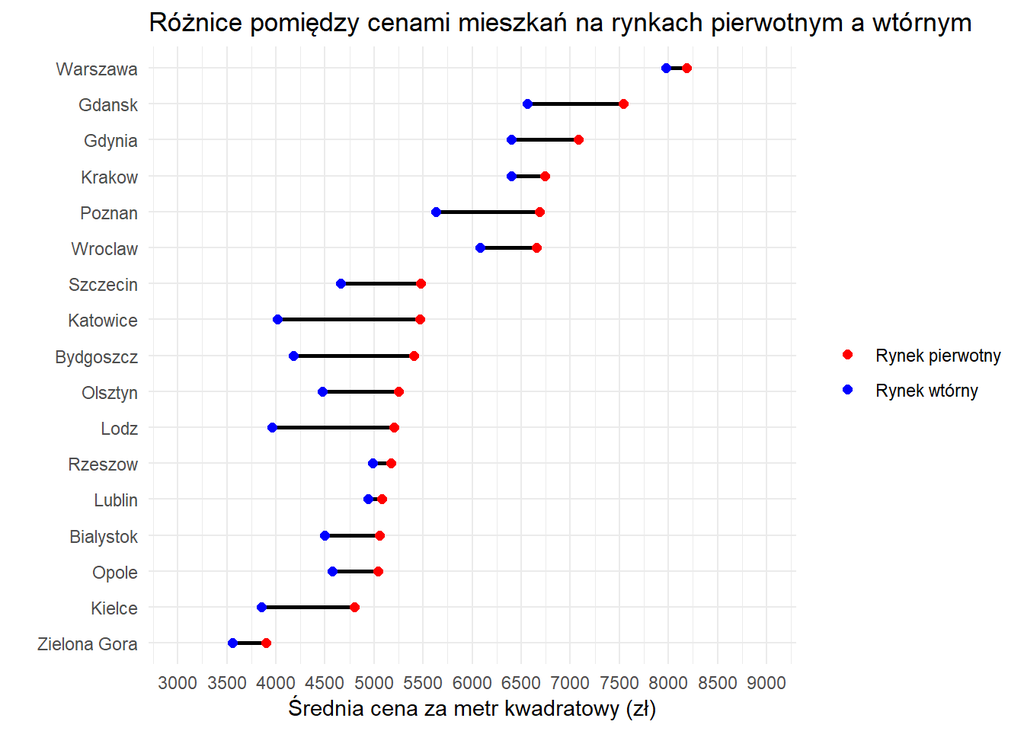

```r
library(ggplot2)
dane <- read.csv("dane.csv", sep = ";")
ggplot(data = dane) +
  geom_segment(aes(x = dane$wtorny, y = reorder(dane$miasto, dane$pierwotny),
                   xend = dane$pierwotny, yend = reorder(dane$miasto, dane$pierwotny)),
               size = 1, col = "black") +
  geom_point(aes(x = dane$wtorny, y = reorder(dane$miasto, dane$pierwotny),
                 colour = "Rynek wtórny"), size = 2)  +
  geom_point(aes(x = dane$pierwotny, y = reorder(dane$miasto, dane$pierwotny),
                 colour = "Rynek pierwotny"), size = 2) +
  scale_color_manual(values = c("Rynek wtórny" = "blue", "Rynek pierwotny" = "red")) +
  scale_x_continuous(name = "Średnia cena za metr kwadratowy (zł)", limits = c(3000, 9000),
                     breaks = seq(0, 9000, 500)) +
  scale_y_discrete(name = "") +
  ggtitle("Różnice pomiędzy cenami mieszkań na rynkach pierwotnym a wtórnym")+
  labs(colour = "")+
  theme_minimal()
```

# Wyjaśnienie

Zaproponowany przez Bartka wykres w sposób mniej lub bardziej zamierzony porównywał różnice między cenami na rynkach pierwotnym a wtórnym. Wykres słupokowy z dwoma kategoriami oczywiście nie jest złym pomysłem na wykonanie tego zadania, jednakże ja uważam, że zaproponowany przeze mnie wykres różnic jest lepszy. Przede wszystkim pozwala szybko ocenić przybliżoną różnicę pomiędzy jedną a drugą kategorią nawet bez znajomości dokładnych wartości. Pomaga w tym belka łącząca jedną wartość z drugą, której długość jest wprost proporcjonalan do różnicy, zaś gęsta podziałka pozwala jeszcze lepiej to ocenić. Celowo nie ustawiłem skali osi poziomej w zerze ponieważ moim zdaniem nie prowadzi to w tym przypadku do jakichkolwiek niedomówień, wręcz przeciwnie zwiększa przejrzystość. Jest tak ponieważ gdyby skala zaczynała się w punkcie zero, wykres miałby dużo mniejszą dokładność, wszak pierwsze wartość pojawiają się dopiero przy 3500zł.